# VAR Project

Hewson

April 22, 2022

This paper will discuss the relationship between Personal Income and the Consumer Price Index. Using a Vector AutoRegression (VAR) model, this paper will explore these two measures of economic health as they relate to each other. In short, Personal Income and the CPI are tightly linked together.

### Choosing the Variables

This paper will be using Personal Income and Consumer Price Index to explore their use as measures of economic health.

From FRED, Personal Income (PI) is defined as “the income that persons receive in return for their provision of labor, land, and capital used in current production and the net current transfer payments that they receive from business and from government.[…] (PI) is equal to national income minus corporate profits with inventory valuation and capital consumption adjustments, taxes on production and imports less subsidies, contributions for government social insurance, net interest and miscellaneous payments on assets, business current transfer payments (net), current surplus of government enterprises, and wage accruals less disbursements, plus personal income receipts on assets and personal current transfer receipts.”[1]

PI is measured in billions of dollars monthly and seasonally adjusted. It should be noted, PI is not the same as median income or average income, but rather a complete total for all persons and their collective income.

Consumer Price Index for All Urban Consumers: All Items in U.S. City Average (CPIAUCSL) is defined as “a price index of a basket of goods and services paid by urban consumers. Percent changes in the price index measure the inflation rate between any two time periods. The most common inflation metric is the percent change from one year ago. It can also represent the buying habits of urban consumers. This particular index includes roughly 88 percent of the total population, accounting for wage earners, clerical workers, technical workers, self-employed, short-term workers, unemployed, retirees, and those not in the labor force.”[2]

These variables were selected for their intrinsic link. The more income one has, the more they have to spend on goods, thus increasing the basket of goods used in the CPI.

For ease of reading, a chart describing the variables is provided below:

### Describe the Variables

| Variable | Description |  |
| --- | --- | --- |
| PI | Personal Income, Billions of dollars, Monthly, Seasonally Adjusted Annual Rate |  |
| CPIAUCSL | Consumer Price Index for All Urban Consumers: All Items, Percent, Monthly, Seasonally Adjusted |  |

```r
require(fpp3)
require(tidyverse)
require(dplyr)
require(tidyquant)
require(lubridate)
require(timetk)
require(vars)
require(lmtest)
require(kableExtra)
```

```r
varList <- c("PI", "CPIAUCSL")
X <- tq_get(varList, get = "economic.data", from = "1960-01-01") %>%
  mutate(Month = yearmonth(date)) %>% dplyr::select(-date) %>%
  as_tsibble(index = Month, key = symbol)
Xw <- X %>%
  pivot_wider(names_from = symbol, values_from = price) %>%
  as_tsibble()
```

### Determining the Model

With the variables loaded, the analysis can begin.

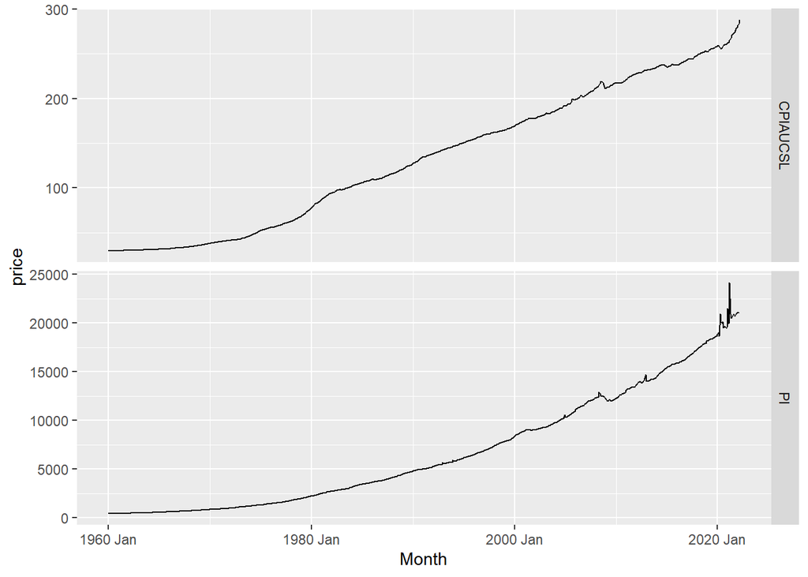

```r
X %>% ggplot(aes(x = Month, y = price)) +
  geom_line() +
  facet_grid(vars(symbol), scales = "free_y")
```

```r
X %>%
  features(price, unitroot_ndiffs) %>%
  kable(format = "html", table.attr = "style='width:30%;' ") %>%
  kableExtra::kable_styling()
```

| symbol | ndiffs |
| --- | --- |
| CPIAUCSL | 2 |
| PI | 2 |

This test demonstrates that there are at least two unit roots in these variables. In other words, these variables contain two unit roots and are therefore non-stationary. Essentially, these are dynamic variables. The table below further shows that Personal Income is non-stationary, as evidenced by the low P-value 0.01.

```r
X %>% filter(symbol == "PI") %>%
  features(log(price), unitroot_kpss) %>%
  kable(format = "html", table.attr = "style='width:30%;' ") %>%
  kableExtra::kable_styling()
```

| symbol | kpss_stat | kpss_pvalue |
| --- | --- | --- |
| PI | 10.54586 | 0.01 |

This is important because this will impact lags in the data later on.

With the unit root tests out of the way, we can officially begin to model the relationship between Personal Income and CPI.

### Producing the Results

To actually use this dataset, we must fist reformat the data into a version that cna read in by the packages loaded in earlier. This process is different for each variable due to differences in data types.

For Personal Income, the process is:
$$gPI = 100 * \delta(log(PI))$$
where $gPI$ is the change in Personal Income.

For CPI, the process is:
$$dCPI = \delta(CPIAUCSL)$$
where $dCPI$ is the change in CPI.

```r
ZCPI <- Xw %>%
  mutate(gPI = 100 * difference(log(PI)),
         dCPI = difference(CPIAUCSL), lag = 1) %>%
  dplyr::select(gPI, dCPI) %>%
  tidyr::drop_na()
zlead <- as.ts(ZCPI, start = c(1960,2), frequency = 12)
```

With the variables modified to taste, we can now officially begin the VAR modeling process. A VAR model is essentially a reduced form dynamic multivariate regression that is useful in studying time series data.

```r
require(vars)
# put variable in order: CPI, gPI
zl <- zlead[,c(2,1)]
tmp <- VARselect(zl,lag.max=12,type="const")
tmp
```

```
## $selection
## AIC(n)  HQ(n)  SC(n) FPE(n)
##     12     12      1     12
##
## $criteria
##                 1          2         3          4          5          6
## AIC(n) -1.7674627 -1.7796129 -1.805704 -1.8091984 -1.8006100 -1.8323173
## HQ(n)  -1.7529475 -1.7554209 -1.771835 -1.7656528 -1.7473876 -1.7694181
## SC(n)  -1.7298326 -1.7168960 -1.717900 -1.6963081 -1.6626329 -1.6692535
## FPE(n)  0.1707657  0.1687035  0.164359  0.1637858  0.1651988  0.1600435
##                 7         8          9         10         11         12
## AIC(n) -1.8293328 -1.820620 -1.8683180 -1.8788002 -1.9651323 -1.9940571
## HQ(n)  -1.7567568 -1.738367 -1.7763884 -1.7771938 -1.8538491 -1.8730971
## SC(n)  -1.6411822 -1.607383 -1.6299940 -1.6153894 -1.6766348 -1.6804728
## FPE(n)  0.1605225  0.161928  0.1543867  0.1527781  0.1401431  0.1361492
```

```r
pl <- tmp$selection[2]
```

This above chart tells us the appropriate number of lags to use in the VAR model. 12 lags ought to be enough (AIC = 12) and makes sense, as this data is measured in months and there are 12 months in a year.

From here, the VAR model can be built.

```r
# estimate the VAR(p)
var.CPI <- VAR(zl,p=pl,type="const")
summary(var.CPI)
```

```
##
## VAR Estimation Results:
## =========================
## Endogenous variables: dCPI, gPI
## Deterministic variables: const
## Sample size: 733
## Log Likelihood: -1299.342
## Roots of the characteristic polynomial:
## 0.9618 0.9325 0.9325 0.925 0.925 0.9234 0.9234 0.8986 0.8986 0.8877 0.8877  0.88  0.88 0.8786 0.8786 0.8717 0.8717 0.8656 0.8656 0.8406 0.8406 0.837 0.8147 0.4665
## Call:
## VAR(y = zl, p = pl, type = "const")
##
##
## Estimation results for equation dCPI:
## =====================================
## dCPI = dCPI.l1 + gPI.l1 + dCPI.l2 + gPI.l2 + dCPI.l3 + gPI.l3 + dCPI.l4 + gPI.l4 + dCPI.l5 + gPI.l5 + dCPI.l6 + gPI.l6 + dCPI.l7 + gPI.l7 + dCPI.l8 + gPI.l8 + dCPI.l9 + gPI.l9 + dCPI.l10 + gPI.l10 + dCPI.l11 + gPI.l11 + dCPI.l12 + gPI.l12 + const
##
##           Estimate Std. Error t value Pr(>|t|)
## dCPI.l1   0.600719   0.037258  16.123  < 2e-16 ***
## gPI.l1    0.017637   0.013675   1.290 0.197570
## dCPI.l2  -0.146716   0.043473  -3.375 0.000779 ***
## gPI.l2    0.040521   0.014558   2.783 0.005522 **
## dCPI.l3   0.059619   0.043734   1.363 0.173247
## gPI.l3    0.049558   0.014549   3.406 0.000696 ***
## dCPI.l4   0.114198   0.043670   2.615 0.009112 **
## gPI.l4    0.012384   0.014243   0.869 0.384872
## dCPI.l5  -0.051721   0.044026  -1.175 0.240474
## gPI.l5   -0.031331   0.014147  -2.215 0.027097 *
## dCPI.l6   0.037436   0.043992   0.851 0.395076
## gPI.l6   -0.051018   0.014322  -3.562 0.000393 ***
## dCPI.l7   0.050605   0.044003   1.150 0.250525
## gPI.l7   -0.010928   0.014391  -0.759 0.447891
## dCPI.l8   0.019185   0.043988   0.436 0.662876
## gPI.l8   -0.004694   0.014488  -0.324 0.746052
## dCPI.l9   0.019742   0.044052   0.448 0.654174
## gPI.l9    0.003132   0.014480   0.216 0.828803
## dCPI.l10  0.090728   0.044302   2.048 0.040933 *
## gPI.l10   0.009884   0.016519   0.598 0.549810
## dCPI.l11  0.099028   0.043542   2.274 0.023247 *
## gPI.l11   0.012368   0.017095   0.723 0.469613
```

[output cut: 46 more lines]

```
## Residual standard error: 0.9943 on 708 degrees of freedom
## Multiple R-Squared: 0.3683,  Adjusted R-squared: 0.3469
## F-statistic:  17.2 on 24 and 708 DF,  p-value: < 2.2e-16
##
##
##
## Covariance matrix of residuals:
##          dCPI      gPI
## dCPI  0.12929 -0.02273
## gPI  -0.02273  0.98872
##
## Correlation matrix of residuals:
##          dCPI      gPI
## dCPI  1.00000 -0.06357
## gPI  -0.06357  1.00000
```

```r
require(lmtest)
cat("H0: gPI does not cause dCPI,  H1: it does \n")
```

```
## H0: gPI does not cause dCPI,  H1: it does
```

```r
grangertest(dCPI ~ gPI,order=pl,data=zl)
```

|  | Res.Df | Df | F | Pr(>F) |
| --- | --- | --- | --- | --- |
| 1 | 708 | NA | NA | NA |
| 2 | 720 | -12 | 2.790832 | 0.0009849052 |

```r
cat("\nH0: dCPI does not cause gPI,  H1: it does\n")
```

```
##
## H0: dCPI does not cause gPI,  H1: it does
```

```r
grangertest(gPI ~ dCPI,order=pl,data=zl)
```

|  | Res.Df | Df | F | Pr(>F) |
| --- | --- | --- | --- | --- |
| 1 | 708 | NA | NA | NA |
| 2 | 720 | -12 | 2.885544 | 0.0006638913 |

Once again, the data is very closely linked. The F-test results are very similar, thus making it difficult difficult to determine which variable leads. Running an impulse response can help visualize the data so we can better determine the leading data.

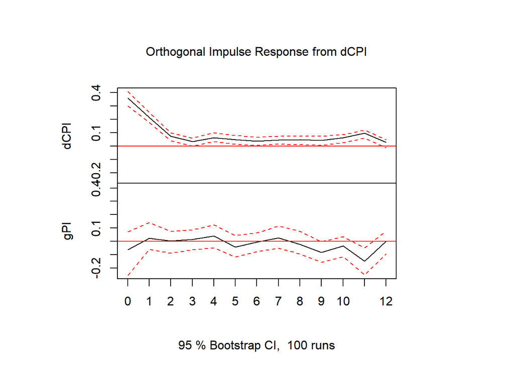

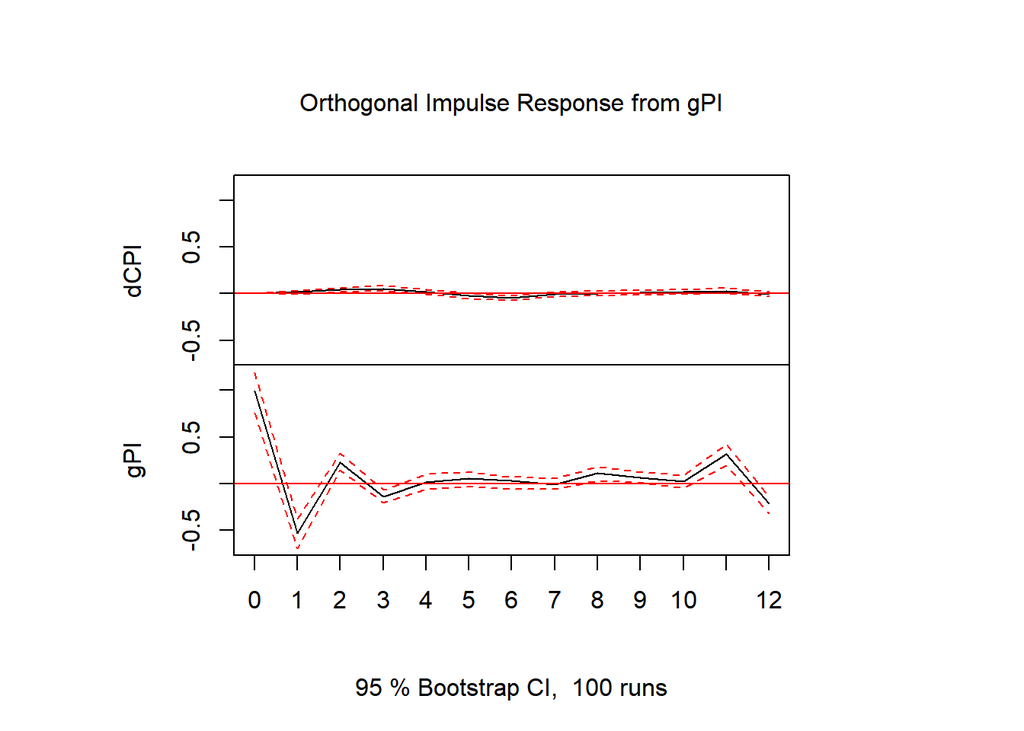

```r
plot(irf(var.CPI, n.ahead = 12, boot = TRUE ))
```

```r
fevd(var.CPI, n.ahead = 12)
```

```
## $dCPI
##            dCPI         gPI
##  [1,] 1.0000000 0.000000000
##  [2,] 0.9982573 0.001742734
##  [3,] 0.9890126 0.010987385
##  [4,] 0.9737762 0.026223793
##  [5,] 0.9722964 0.027703638
##  [6,] 0.9699453 0.030054695
##  [7,] 0.9596834 0.040316590
##  [8,] 0.9597958 0.040204169
##  [9,] 0.9602629 0.039737138
## [10,] 0.9598285 0.040171523
## [11,] 0.9587592 0.041240816
## [12,] 0.9569339 0.043066070
##
## $gPI
##              dCPI       gPI
##  [1,] 0.004040919 0.9959591
##  [2,] 0.003524382 0.9964756
##  [3,] 0.003397579 0.9966024
##  [4,] 0.003507344 0.9964927
##  [5,] 0.004680232 0.9953198
##  [6,] 0.005913134 0.9940869
##  [7,] 0.005921856 0.9940781
##  [8,] 0.006407324 0.9935927
##  [9,] 0.006715818 0.9932842
## [10,] 0.011699124 0.9883009
## [11,] 0.012482259 0.9875177
## [12,] 0.026250363 0.9737496
```

### References

[1] - https://fred.stlouisfed.org/series/PI [2] - https://fred.stlouisfed.org/series/CPIAUCSL